# DataLab Cup 5: Deep Reinforcement Learning

Shan-Hung Wu & DataLab

Fall 2017

## Task: Flappy Bird

Given a screen shot of flappy bird, your task is to select action that maximize total reward.

[figure not shown]

## Environment

We will use flappy bird in [pygame learning environment](http://pygame-learning-environment.readthedocs.io/en/latest/user/home.html) as our training environment, please install it before going through. The environment provide some useful function that can easily get screen for each step.

To make thing easy, we replace background with black color and make all pipes and birds the same, please unzip the `asset.zip` file on [kaggle](https://www.kaggle.com/t/a7c350c765104cada44097b560238755) and overrite this folder in `PyGame-Learning-Environment\ple\games\flappybird\assets`.

```
couldn't import doomish
Couldn't import doom
(288, 512, 3)
(288, 512)
```

[figure not shown]

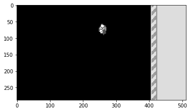

```python
# import package needed
%matplotlib inline
import matplotlib.pyplot as plt
import os
os.environ["SDL_VIDEODRIVER"] = "dummy" # make window not appear
import tensorflow as tf
import numpy as np
import skimage.color
import skimage.transform
from ple.games.flappybird import FlappyBird
from ple import PLE
game = FlappyBird()
env = PLE(game, fps=30, display_screen=False) # environment interface to game
env.reset_game()
env.act(0) # dummy input to get screen correct

# get rgb screen
screen = env.getScreenRGB()
plt.imshow(screen)
print(screen.shape)

# get grayscale screen
plt.figure()
screen = env.getScreenGrayscale()
plt.imshow(screen, cmap='gray')
print(screen.shape)
```

## Input/Output format

We will give you a list of previous screen containing current screen, where dimension of frame is 288 x 512 (grayscale). The output of your agent is action to select (0 or 1).

## Implementation

Your agent need to implement the following function:

```
class YourAgent:
    def select_action(self, input_screens, sess):
        """
        args:
            input_screens: list of frames preprocessed by preprocess function
            sess : tensorflow Session
        output:
            action: int (0 or 1)
        """
    def preprocess(self, screen):
        """
        this function preprocess screen that will be used in select_action function

        args:
            screen: screen to do some preprocessing
        output:
            preprocessed_screen
        """
```

```python
# E.g.
class Agent:
    def select_action(self, input_screens, sess):
        # epsilon-greedy
        if np.random.rand() < self.exploring_rate:
            action = np.random.choice(num_action) # Select a random action
        else:
            input_screens = np.array(input_screen[-1]).transpose([1,2,0]) # select current screen
            feed_dict = {
                self.input_screen: input_screen[None,:],
            }
            action = sess.run(self.pred, feed_dict=feed_dict)[0] # Select action with the highest q
        return action

    def preprocess(self, screen):
        screen = skimage.transform.resize(screen, [80, 80])
        return screen
```

## Model

To achieve the task, you can use either DQN or Policy Network or combine both to train your agent. Please refer lab16-2_DQN & Policy Network

### DQN

[figure not shown]

### Policy Network

[figure not shown]

### Actor-Critic

[figure not shown]

## Evaluation

We will use the same scenes to evaluate performance of your agent.

### Evaluate sample code

The following are sample code for showing how will we evaluate your agent.

```python
def evaluate_step(agent, seed, sess):
    game = FlappyBird()
    env = PLE(game, fps=30, display_screen=False, rng=np.random.RandomState(seed))
    env.reset_game()
    env.act(0) # dummy input
    # grayscale input screen for this episode
    input_screens = [agent.preprocess(env.getScreenGrayscale())]
    t = 0
    while not env.game_over():
        # feed four previous screen, select an action
        action = agent.select_action(input_screens, sess)
        # execute the action and get reward
        reward = env.act(env.getActionSet()[action])  # reward = +1 when pass a pipe, -5 when die
        # observe the result
        screen_plum = env.getScreenGrayscale()  # get next screen
        # append grayscale screen for this episode
        input_screens.append(agent.preprocess(screen_plum))
        t+=1
        if t >= 1000: # maximum score to prevent run forever
            break
    return t
def evaluate(agent, sess):
    scores = []
    for seed in [...some hidden seed...]:
        score = evaluate_step(agent, seed, sess)
        scores.append(score)
    return scores
```

Above code with hidden seed is compiled in **evaluate.pyc**, to use it, run following code.

```python
from evaluate import evaluate
agent = YourAgent() # init your agent, load checkpoint...
scores = evaluate(agent, sess) # evaluate
```

### Submission

submmit scores.csv generated by the following code to [DataLabCup: Deep Reinforcement Learning](https://www.kaggle.com/t/a7c350c765104cada44097b560238755)

```python
import pandas as pd
df = pd.DataFrame({
    'scores': scores
})
df.to_csv('./scores.csv')
```

## Hints

I collect some papers that may useful in this task

#### Training: [Dueling Network Architectures for Deep Reinforcement Learning](https://arxiv.org/abs/1511.06581)

The paper propose a model architecture that learn a state-value for each state and give a baseline to action-value. The result speed up training.

[figure not shown]

#### Training: [Asynchronous Methods for Deep Reinforcement Learning](https://arxiv.org/abs/1602.01783)

The paper using asychronous agent in different environment, which collect different experience and therefore stabilize training.

[figure not shown]

#### Training: [Prioritized Experience Replay](https://arxiv.org/abs/1511.05952)

The paper give priority to experiences in replay buffer. The higher loss with higher priority, which give scene unseen before more chance to train.

#### Training: [Deep Reinforcement Learning with Double Q-learning](https://arxiv.org/abs/1509.06461)

The paper say that origin Q-learning over-estimate Q-value and propose a mitigated function. which stabilize training.

#### Training: [Playing FPS Games with Deep Reinforcement Learning](https://arxiv.org/abs/1609.05521)

The paper add a auxiliary layer to model and claim that it speed up training.